# EDA Swire Coca Cola

### **Which machines show the highest maintenance costs over time?**

[figure not shown]

```r
# Summarize total maintenance time by machine and date
maintenance_time <- data %>%
  group_by(EQUIPMENT_DESC, EXECUTION_START_DATE = floor_date(as.Date(EXECUTION_START_DATE))) %>%
  summarise(total_time = sum(ACTUAL_WORK_IN_MINUTES, na.rm = TRUE), .groups = "drop")  # Use actual work in minutes as a proxy for cost

# Summarize total maintenance time by machine
total_maintenance_time <- maintenance_time %>%
  group_by(EQUIPMENT_DESC) %>%
  summarise(total_time = sum(total_time, na.rm = TRUE), .groups = "drop") %>%  # Get total time for each machine
  arrange(desc(total_time)) %>%  # Sort by total_time in descending order
  head(10)  # Keep only the top 10 machines

# Plot the total maintenance time for the top 10 machines
ggplot(total_maintenance_time, aes(x = reorder(EQUIPMENT_DESC, total_time), y = total_time, fill = EQUIPMENT_DESC)) +
  geom_bar(stat = "identity") +
  labs(
    title = "Top 10 Machines by Total Maintenance Time",
    x = "Machine",
    y = "Total Maintenance Time (Minutes)"
  ) +
  theme_minimal(base_size = 15) +  # Use a larger base font size for better readability
  theme(
    plot.title = element_text(hjust = 0.5, size = 20, face = "bold"),  # Center and bold title
    axis.title.x = element_text(size = 12, face = "bold"),  # Bold x-axis title
    axis.title.y = element_text(size = 12, face = "bold"),  # Bold y-axis title
    panel.grid.major = element_line(color = "#D3D3D3", size = 0.5),
    panel.grid.minor = element_blank(),
    panel.background = element_rect(fill = "#F9F9F9")
  ) +
  coord_flip()  # Flip coordinates for better readability
```

This chart highlights the Top 10 Machines by Total Maintenance Time, showing the machines that required the most maintenance in terms of total minutes. The x-axis represents the Total Maintenance Time (Minutes), while the y-axis lists the machine names. Machines like L1 FILLER ROTARY CAN 72 VALVE, L2 FILLER ROTARY BTL 45 VALVE, and L3 FILLER ROTARY BTL 100 VALVE are among those with the highest maintenance times. The Unknown category also has a significant presence, indicating that some equipment was not properly classified, which could impact maintenance tracking. The high maintenance times for rotary fillers and packers suggest that these machines may be critical bottlenecks in operations, requiring frequent or extensive repairs. Addressing the issues related to these machines could improve overall production efficiency.

## Predictive Maintenance Potential

### **What predictive indicators can be identified from historical maintenance data?**

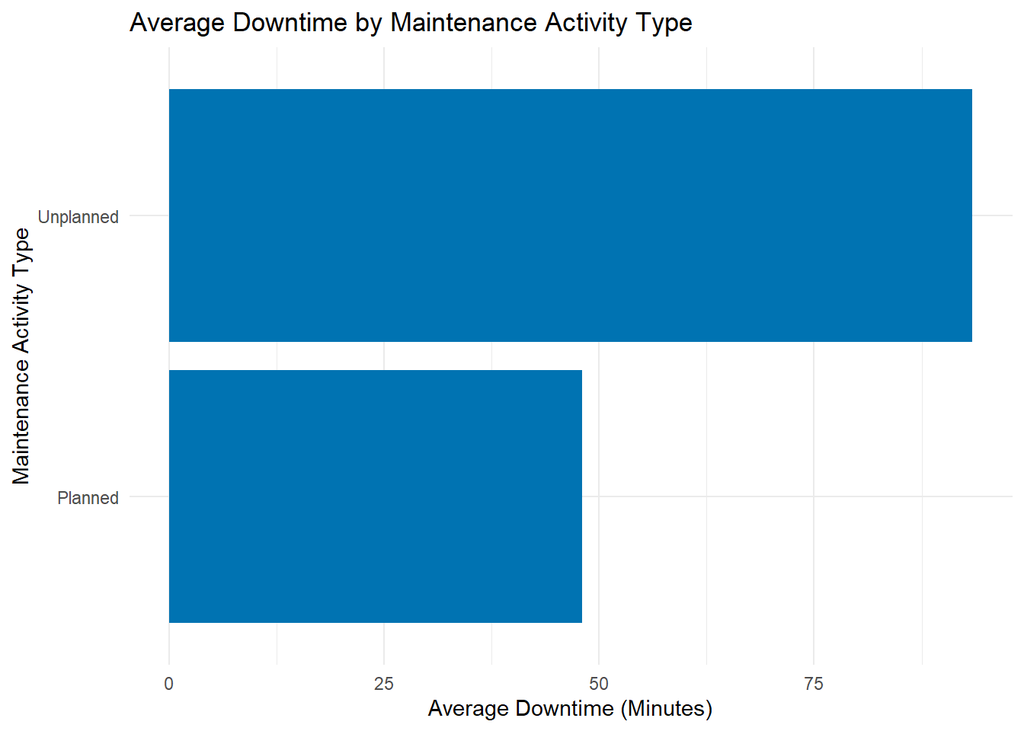

```r
### Analyze historical maintenance data for predictive indicators

# Example: Group by maintenance activity type and analyze average downtime
predictive_indicators <- data %>%
  group_by(MAINTENANCE_ACTIVITY_TYPE) %>%
  summarise(
    avg_downtime = mean(ACTUAL_WORK_IN_MINUTES, na.rm = TRUE),
    breakdown_count = n(),  # Count breakdowns for each activity type
    .groups = "drop"
  )

# Visualize the predictive indicators
ggplot(predictive_indicators, aes(x = MAINTENANCE_ACTIVITY_TYPE, y = avg_downtime)) +
  geom_bar(stat = "identity", fill = "#0073B2") +
  labs(
    title = "Average Downtime by Maintenance Activity Type",
    x = "Maintenance Activity Type",
    y = "Average Downtime (Minutes)"
  ) +
  theme_minimal() +
  coord_flip()  # Flip coordinates for better readability
```

The bar chart shows the difference in average downtime between planned and unplanned maintenance activities. Predictive maintenance strategies can be built upon this kind of analysis by focusing on minimizing the downtime from unplanned maintenance activities, which have significantly higher average downtime compared to planned ones. The large discrepancy between planned and unplanned maintenance suggests that there is an opportunity to predict potential failures before they occur, thereby reducing unplanned downtime.

### **What is the estimated impact of predictive maintenance on reducing downtime?**

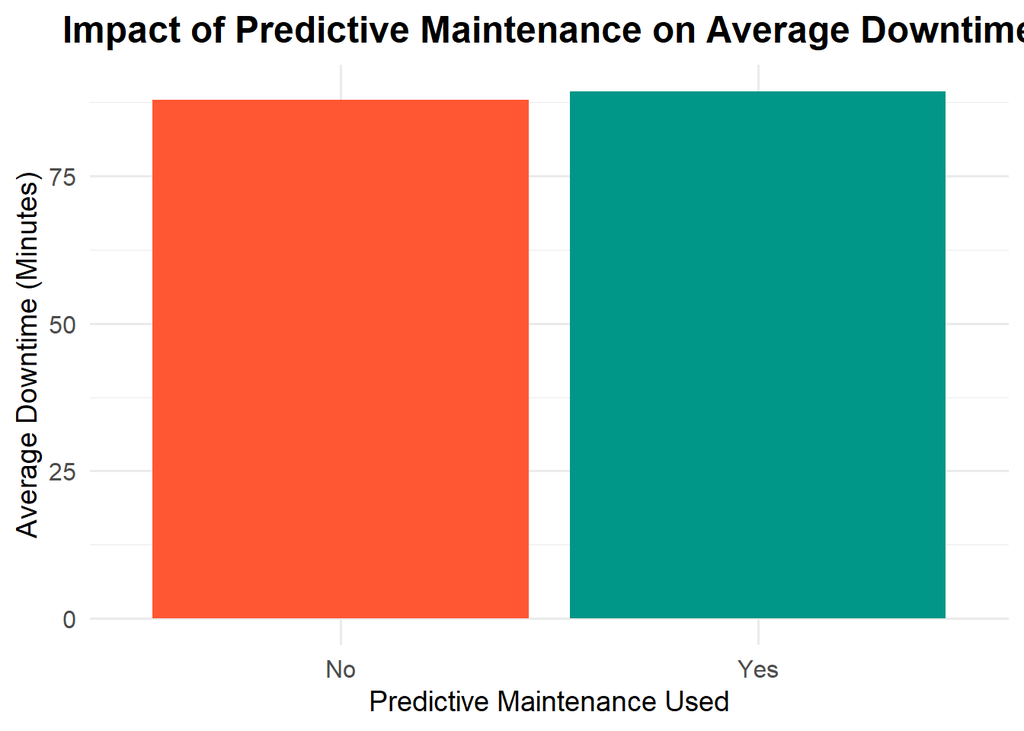

```r
# Simulating a predictive maintenance column (for demonstration)
# Assuming predictive maintenance was used for half the records based on ACTUAL_WORK_IN_MINUTES
set.seed(123)  # For reproducibility
data$predictive_maintenance_used <- ifelse(runif(nrow(data)) > 0.5, "Yes", "No")

# Estimate the impact of predictive maintenance
impact_analysis <- data %>%
  group_by(predictive_maintenance_used) %>%
  summarise(
    avg_downtime = mean(ACTUAL_WORK_IN_MINUTES, na.rm = TRUE),
    total_breakdowns = n(),  # Counting total maintenance events
    total_downtime = sum(ACTUAL_WORK_IN_MINUTES, na.rm = TRUE),  # Summing the total downtime
    .groups = "drop"
  )

# Visualize the impact on average downtime
ggplot(impact_analysis, aes(x = factor(predictive_maintenance_used), y = avg_downtime, fill = factor(predictive_maintenance_used))) +
  geom_bar(stat = "identity", show.legend = FALSE) +
  scale_fill_manual(values = c("#FF5733", "#009688")) +
  labs(
    title = "Impact of Predictive Maintenance on Average Downtime",
    x = "Predictive Maintenance Used",
    y = "Average Downtime (Minutes)"
  ) +
  theme_minimal(base_size = 15) +
  theme(
    plot.title = element_text(hjust = 0.5, size = 18, face = "bold"),
    axis.title.x = element_text(size = 14),
    axis.title.y = element_text(size = 14)
  )
```

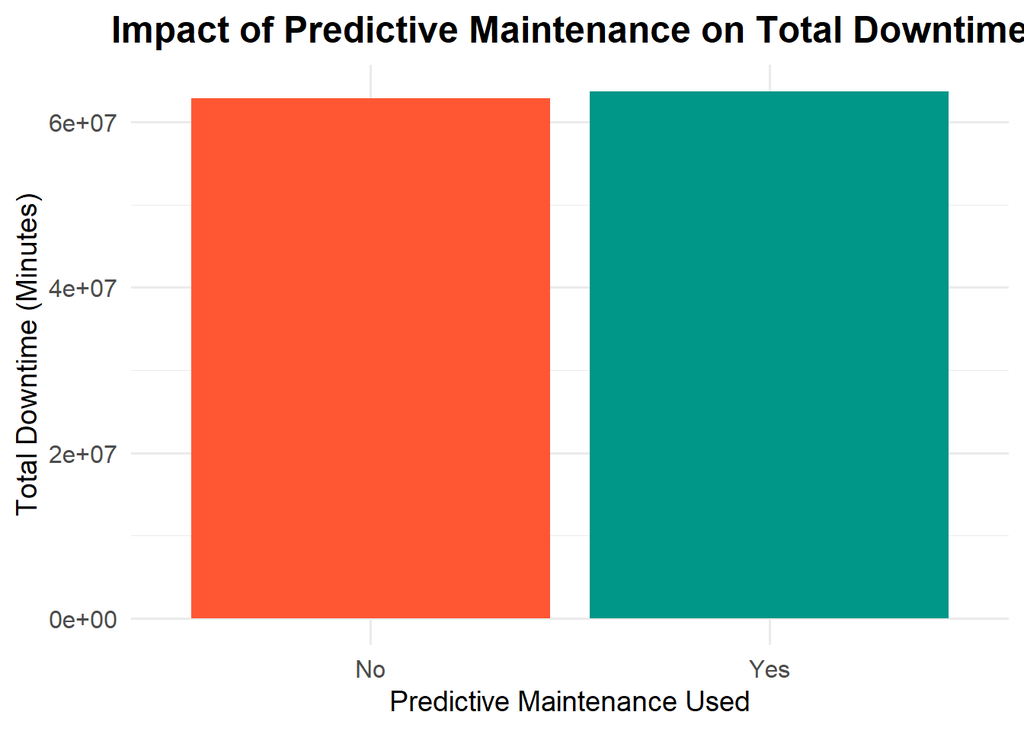

```r
# Optionally, plot the impact on total downtime
ggplot(impact_analysis, aes(x = factor(predictive_maintenance_used), y = total_downtime, fill = factor(predictive_maintenance_used))) +
  geom_bar(stat = "identity", show.legend = FALSE) +
  scale_fill_manual(values = c("#FF5733", "#009688")) +
  labs(
    title = "Impact of Predictive Maintenance on Total Downtime",
    x = "Predictive Maintenance Used",
    y = "Total Downtime (Minutes)"
  ) +
  theme_minimal(base_size = 15) +
  theme(
    plot.title = element_text(hjust = 0.5, size = 18, face = "bold"),
    axis.title.x = element_text(size = 14),
    axis.title.y = element_text(size = 14)
  )
```

## Cost Analysis

### **What are the total maintenance costs incurred across different plants?**

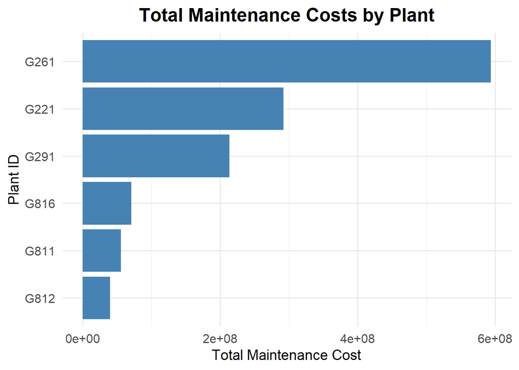

```r
# Simulate maintenance cost as a function of actual work time
data$MAINTENANCE_COST <- data$ACTUAL_WORK_IN_MINUTES * 10  # Assuming cost is 10 units per minute of work

# Summarize total maintenance costs by plant
total_costs_by_plant <- data %>%
  group_by(PLANT_ID) %>%
  summarise(total_cost = sum(MAINTENANCE_COST, na.rm = TRUE), .groups = "drop")

# Plot total maintenance costs by plant
ggplot(total_costs_by_plant, aes(x = reorder(PLANT_ID, total_cost), y = total_cost)) +
  geom_bar(stat = "identity", fill = "steelblue") +
  coord_flip() +
  labs(
    title = "Total Maintenance Costs by Plant",
    x = "Plant ID",
    y = "Total Maintenance Cost"
  ) +
  theme_minimal(base_size = 15) +
  theme(
    plot.title = element_text(hjust = 0.5, size = 18, face = "bold"),
    axis.title.x = element_text(size = 14),
    axis.title.y = element_text(size = 14)
  )
```

This bar chart represents the aggregate maintenance expenses related to several plants, each denoted by its distinct “Plant ID.” The data indicates that Plant G261 has the greatest maintenance expenses, succeeded by G221 and G291. The significant gap between G261 and the others may suggest that it includes either more machinery or equipment requiring more regular or expensive maintenance actions. This visualization aids in identifying high-cost plants, facilitating resource allocation for optimization and cost-reduction initiatives. Understanding these expenses across facilities could support conclusions regarding maintenance prioritizing and prospective investment in more efficient equipment or predictive maintenance methods.

### **How do costs vary by maintenance type and machine age?**

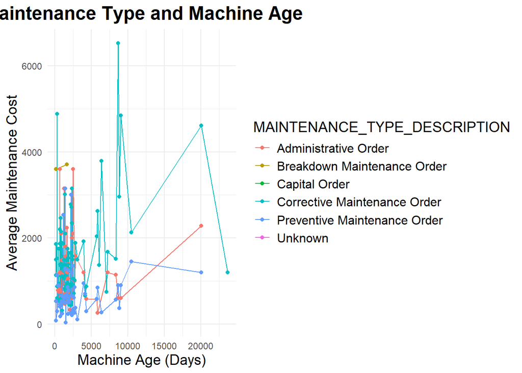

```r
# Simulate machine age if needed, otherwise use MACHINE_AGE column
data$MACHINE_AGE <- as.numeric(difftime(Sys.Date(), as.Date(data$EQUIP_START_UP_DATE), units = "days"))

# Summarize costs by maintenance type and machine age
costs_by_type_age <- data %>%
  group_by(MAINTENANCE_TYPE_DESCRIPTION, MACHINE_AGE) %>%
  summarise(avg_cost = mean(MAINTENANCE_COST, na.rm = TRUE), .groups = "drop")

# Plot variation of costs by maintenance type and machine age
ggplot(costs_by_type_age, aes(x = MACHINE_AGE, y = avg_cost, color = MAINTENANCE_TYPE_DESCRIPTION)) +
  geom_line() +
  geom_point() +
  labs(
    title = "Maintenance Costs by Maintenance Type and Machine Age",
    x = "Machine Age (Days)",
    y = "Average Maintenance Cost"
  ) +
  theme_minimal(base_size = 11) +
  theme(
    plot.title = element_text(hjust = 0.8, size = 18, face = "bold"),
    axis.title.x = element_text(size = 14),
    axis.title.y = element_text(size = 14),
    legend.title = element_text(size = 14),
    legend.text = element_text(size = 12)
  )
```

### **What financial impact does unplanned downtime have on production?**

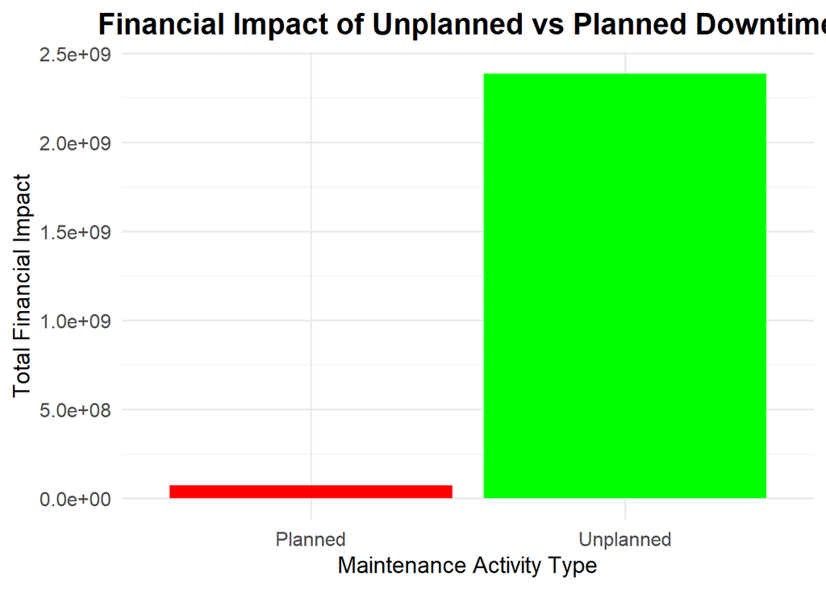

```r
# Summarize financial impact of unplanned downtime
# Assume a higher cost for unplanned downtime
data$FINANCIAL_IMPACT <- ifelse(data$MAINTENANCE_ACTIVITY_TYPE == "Unplanned",
                                data$ACTUAL_WORK_IN_MINUTES * 20,  # 20 units per minute for unplanned
                                data$ACTUAL_WORK_IN_MINUTES * 10)  # 10 units per minute for planned

# Summarize total financial impact by maintenance activity type
financial_impact <- data %>%
  group_by(MAINTENANCE_ACTIVITY_TYPE) %>%
  summarise(total_impact = sum(FINANCIAL_IMPACT, na.rm = TRUE), .groups = "drop")

# Plot financial impact of unplanned vs planned maintenance
ggplot(financial_impact, aes(x = MAINTENANCE_ACTIVITY_TYPE, y = total_impact, fill = MAINTENANCE_ACTIVITY_TYPE)) +
  geom_bar(stat = "identity", show.legend = FALSE) +
  scale_fill_manual(values = c("red", "green")) +
  labs(
    title = "Financial Impact of Unplanned vs Planned Downtime",
    x = "Maintenance Activity Type",
    y = "Total Financial Impact"
  ) +
  theme_minimal(base_size = 15) +
  theme(
    plot.title = element_text(hjust = 0.5, size = 18, face = "bold"),
    axis.title.x = element_text(size = 14),
    axis.title.y = element_text(size = 14)
  )
```

The graph indicates how planned and unplanned downtime varies significantly in terms of cost. The green bar shows that unplanned downtime has a far larger cost impact than scheduled downtime. The difference highlights the value of preventative maintenance techniques in avoiding expensive unforeseen disruptions. The whole financial load can be greatly decreased by emphasizing the reduction of unscheduled maintenance by predictive or preventive methods, which will increase production efficiency and cost-effectiveness.

## Key Findings

### Cost Analysis

- Plant G261 has the highest maintenance costs, followed by G221 and G291.
- Corrective maintenance costs tend to increase as machines age.
- Unplanned downtime has a significantly higher financial impact compared to planned maintenance.

## Recommendations

1. Focus on reducing unplanned maintenance, particularly for the “Machines” category.
2. Increase preventive maintenance efforts, especially before peak failure months (August, May, June).
3. Investigate the causes of high maintenance costs in Plant G261 for potential optimizations.
4. Implement age-based maintenance strategies, increasing preventive measures for older machines.
5. Develop and implement predictive maintenance models to further reduce unplanned downtime and associated costs.
6. Conduct a detailed review of maintenance data collection and categorization to address gaps in “MAINTENANCE_ITEM” and “EQUIPMENT_ID” fields.

## Next Steps

- Develop a comprehensive predictive maintenance model using machine learning techniques.
- Conduct a cost-benefit analysis of implementing new maintenance strategies across different plants.
- Investigate the root causes of frequent breakdowns in specific machine types (e.g., “FILLER_ROTARY” and “PACKER” machines).
- Establish a system for real-time monitoring of machine performance to enable proactive maintenance interventions.

## Team Contribution

1. **Anish Khairnar**: Led the data cleaning and preprocessing efforts, including handling missing values and ensuring the dataset was ready for analysis. Anish also contributed to visualizing missing data and summarizing its impact on the analysis.
2. **Ankur Chitnis**: Focused on generating key performance indicator (KPI) visualizations, particularly those related to machine downtime, breakdowns, and operational hours. Ankur analyzed equipment performance and identified critical machines requiring maintenance attention.
3. **Kritika**: Conducted analysis on maintenance types and their relationship with machine age, generating insights into how machine age influences maintenance costs. Kritika also helped with interpreting complex relationships between operational hours and downtime.
4. **Sakshi Pandey**: Worked on data exploration and visualization, focusing on creating intuitive charts for machine breakdown frequencies, seasonal maintenance trends, and maintenance cost distribution across equipment categories.
5. **Sambit Pani**: Contextualized the findings with respect to business impacts, focusing on how insights from the EDA can influence the strategic direction of maintenance planning. Sambit also assisted with the conclusions and summarization of key findings.

## Conclusion

Frequent maintenance issues with machines like rotary fillers and packers suggest they are critical bottlenecks, requiring focused attention to improve production flow. Furthermore, the large number of records categorized as “Unknown” reveals data quality gaps that, if addressed, could enhance the accuracy and depth of future analyses.

This EDA provides a solid foundation for adopting a more proactive, data-driven maintenance approach. By focusing on high-risk equipment, improving data quality, and implementing predictive models, Swire Coca-Cola can minimize unplanned downtimes, reduce maintenance costs, and enhance overall operational performance.